# Timing matters: Viticultural land use determines responses in structure and function of fungal stream communities across one growing season

```r
anova(rda_DNA_taxa_hyph_3, by = "margin")
```

```
## Permutation test for rda under reduced model
## Marginal effects of terms
## Permutation: free
## Number of permutations: 999
##
## Model: rda(formula = decostand(DNA_taxa_hyph, "hellinger") ~ timepoint + treatment + Condition(Stream), data = DNA_expl)
##           Df Variance       F Pr(>F)
## timepoint  3 0.087895 13.9657  0.001 ***
## treatment  2 0.036549  8.7109  0.001 ***
## Residual  90 0.188809
## ---
## Signif. codes:  0 '***' 0.001 '**' 0.01 '*' 0.05 '.' 0.1 ' ' 1
```

```r
# timepoint  3 0.087895 13.9657  0.001 ***
# treatment  2 0.036549  8.7109  0.001 ***
# both together explains 26.7%

rda_DNA_taxa_hyph_4 <- rda(decostand(DNA_taxa_hyph, "hellinger")
                        ~ timepoint + treatment + timepoint:treatment +  Condition(Stream), data = DNA_expl)
summary(rda_DNA_taxa_hyph_4, display = NULL)
```

```
##
## Call:
## rda(formula = decostand(DNA_taxa_hyph, "hellinger") ~ timepoint +      treatment + timepoint:treatment + Condition(Stream), data = DNA_expl)
##
## Partitioning of variance:
##               Inertia Proportion
## Total          0.4640     1.0000
## Conditioned    0.1511     0.3257
## Constrained    0.1386     0.2988
## Unconstrained  0.1743     0.3755
##
## Eigenvalues, and their contribution to the variance
## after removing the contribution of conditiniong variables
##
## Importance of components:
##                          RDA1    RDA2    RDA3     RDA4     RDA5     RDA6
## Eigenvalue            0.07668 0.03965 0.01130 0.005948 0.001966 0.001467
## Proportion Explained  0.24506 0.12672 0.03613 0.019009 0.006284 0.004688
## Cumulative Proportion 0.24506 0.37178 0.40791 0.426916 0.433200 0.437888
##                            RDA7      RDA8      RDA9     RDA10     RDA11     PC1
## Eigenvalue            0.0009467 0.0002689 0.0002063 0.0001485 5.222e-05 0.05945
## Proportion Explained  0.0030257 0.0008594 0.0006592 0.0004747 1.669e-04 0.18999
## Cumulative Proportion 0.4409133 0.4417727 0.4424320 0.4429066 4.431e-01 0.63307
##                           PC2     PC3     PC4     PC5      PC6     PC7      PC8
## Eigenvalue            0.02443 0.02027 0.01654 0.01165 0.008659 0.00770 0.006631
## Proportion Explained  0.07808 0.06477 0.05285 0.03722 0.027675 0.02461 0.021192
## Cumulative Proportion 0.71114 0.77592 0.82876 0.86598 0.893659 0.91827 0.939460
##                            PC9     PC10     PC11     PC12      PC13      PC14
## Eigenvalue            0.004874 0.003959 0.002380 0.001574 0.0009867 0.0009247
## Proportion Explained  0.015578 0.012654 0.007606 0.005029 0.0031534 0.0029552
## Cumulative Proportion 0.955038 0.967691 0.975298 0.980327 0.9834806 0.9864358
##                            PC15      PC16      PC17      PC18      PC19
## Eigenvalue            0.0008058 0.0007059 0.0005591 0.0004326 0.0003613
## Proportion Explained  0.0025754 0.0022562 0.0017868 0.0013825 0.0011547
## Cumulative Proportion 0.9890112 0.9912674 0.9930541 0.9944367 0.9955914
##                            PC20      PC21      PC22      PC23      PC24
## Eigenvalue            0.0003040 0.0002422 0.0002180 0.0001583 0.0001352
## Proportion Explained  0.0009716 0.0007741 0.0006966 0.0005061 0.0004321
## Cumulative Proportion 0.9965630 0.9973371 0.9980337 0.9985398 0.9989719
##                            PC25      PC26      PC27      PC28      PC29
## Eigenvalue            0.0001124 7.129e-05 3.885e-05 3.111e-05 2.539e-05
## Proportion Explained  0.0003591 2.278e-04 1.242e-04 9.942e-05 8.115e-05
## Cumulative Proportion 0.9993310 9.996e-01 9.997e-01 9.998e-01 9.999e-01
##                            PC30      PC31      PC32      PC33      PC34
## Eigenvalue            2.073e-05 1.306e-05 5.340e-06 2.333e-06 1.229e-06
## Proportion Explained  6.624e-05 4.173e-05 1.707e-05 7.455e-06 3.928e-06
## Cumulative Proportion 9.999e-01 1.000e+00 1.000e+00 1.000e+00 1.000e+00
##
## Accumulated constrained eigenvalues
## Importance of components:
##                          RDA1    RDA2    RDA3     RDA4     RDA5     RDA6
## Eigenvalue            0.07668 0.03965 0.01130 0.005948 0.001966 0.001467
## Proportion Explained  0.55308 0.28601 0.08154 0.042904 0.014182 0.010581
## Cumulative Proportion 0.55308 0.83909 0.92063 0.963533 0.977715 0.988296
##                            RDA7      RDA8      RDA9     RDA10     RDA11
## Eigenvalue            0.0009467 0.0002689 0.0002063 0.0001485 5.222e-05
## Proportion Explained  0.0068288 0.0019396 0.0014879 0.0010713 3.767e-04
## Cumulative Proportion 0.9951245 0.9970641 0.9985520 0.9996233 1.000e+00
```

```r
anova(rda_DNA_taxa_hyph_4, by = "margin")
```

```
## Permutation test for rda under reduced model
## Marginal effects of terms
## Permutation: free
## Number of permutations: 999
##
## Model: rda(formula = decostand(DNA_taxa_hyph, "hellinger") ~ timepoint + treatment + timepoint:treatment + Condition(Stream), data = DNA_expl)
##                     Df Variance      F Pr(>F)
## timepoint:treatment  6 0.014552 1.1692  0.249
## Residual            84 0.174257
```

```r
# timepoint:treatment  6 0.014552 1.1692  0.247
# adding an interaction explains 29.9% of variance
# interaction is not significant! Use less complex model for next steps

# model for RDA
rda_DNA_taxa_hyph_5 <- rda(decostand(DNA_taxa_hyph, "hellinger")
                        ~ timepoint + treatment +  Condition(Stream), data = DNA_expl)
summary(rda_DNA_taxa_hyph_5, display = NULL)
```

```
##
## Call:
## rda(formula = decostand(DNA_taxa_hyph, "hellinger") ~ timepoint +      treatment + Condition(Stream), data = DNA_expl)
##
## Partitioning of variance:
##               Inertia Proportion
## Total          0.4640     1.0000
## Conditioned    0.1511     0.3257
## Constrained    0.1241     0.2674
## Unconstrained  0.1888     0.4069
##
## Eigenvalues, and their contribution to the variance
## after removing the contribution of conditiniong variables
##
## Importance of components:
##                          RDA1    RDA2     RDA3     RDA4      RDA5     PC1
## Eigenvalue            0.07636 0.03708 0.008754 0.001230 0.0006578 0.06284
## Proportion Explained  0.24406 0.11850 0.027978 0.003931 0.0021022 0.20084
## Cumulative Proportion 0.24406 0.36255 0.390530 0.394461 0.3965636 0.59741
##                           PC2     PC3     PC4     PC5     PC6      PC7      PC8
## Eigenvalue            0.02571 0.02231 0.01728 0.01476 0.01068 0.008025 0.007319
## Proportion Explained  0.08218 0.07129 0.05521 0.04718 0.03414 0.025649 0.023391
## Cumulative Proportion 0.67958 0.75087 0.80608 0.85326 0.88740 0.913051 0.936442
##                            PC9     PC10     PC11     PC12     PC13      PC14
## Eigenvalue            0.004987 0.004099 0.002561 0.001649 0.001048 0.0009586
## Proportion Explained  0.015937 0.013102 0.008185 0.005269 0.003349 0.0030637
## Cumulative Proportion 0.952379 0.965481 0.973666 0.978935 0.982284 0.9853482
##                            PC15     PC16      PC17      PC18      PC19
## Eigenvalue            0.0008659 0.000753 0.0005738 0.0004651 0.0004232
## Proportion Explained  0.0027675 0.002407 0.0018339 0.0014863 0.0013524
## Cumulative Proportion 0.9881157 0.990522 0.9923562 0.9938425 0.9951949
##                            PC20      PC21      PC22      PC23      PC24
## Eigenvalue            0.0003100 0.0002647 0.0002260 0.0001942 0.0001489
## Proportion Explained  0.0009909 0.0008460 0.0007222 0.0006206 0.0004758
## Cumulative Proportion 0.9961858 0.9970318 0.9977540 0.9983747 0.9988505
##                            PC25      PC26      PC27      PC28      PC29
## Eigenvalue            0.0001341 7.314e-05 4.356e-05 0.0000352 2.756e-05
## Proportion Explained  0.0004286 2.338e-04 1.392e-04 0.0001125 8.807e-05
## Cumulative Proportion 0.9992791 9.995e-01 9.997e-01 0.9997645 9.999e-01
##                            PC30      PC31      PC32      PC33      PC34
## Eigenvalue            2.187e-05 1.479e-05 5.608e-06 2.484e-06 1.366e-06
## Proportion Explained  6.989e-05 4.727e-05 1.792e-05 7.940e-06 4.366e-06
## Cumulative Proportion 9.999e-01 1.000e+00 1.000e+00 1.000e+00 1.000e+00
##
## Accumulated constrained eigenvalues
## Importance of components:
##                          RDA1    RDA2     RDA3     RDA4      RDA5
## Eigenvalue            0.07636 0.03708 0.008754 0.001230 0.0006578
## Proportion Explained  0.61543 0.29881 0.070550 0.009913 0.0053010
## Cumulative Proportion 0.61543 0.91424 0.984786 0.994699 1.0000000
```

```r
anova.cca(rda_DNA_taxa_hyph_5, step = 1000) # model is significant + the best model of all
```

```
## Permutation test for rda under reduced model
## Permutation: free
## Number of permutations: 999
##
## Model: rda(formula = decostand(DNA_taxa_hyph, "hellinger") ~ timepoint + treatment + Condition(Stream), data = DNA_expl)
##          Df Variance      F Pr(>F)
## Model     5  0.12408 11.829  0.001 ***
## Residual 90  0.18881
## ---
## Signif. codes:  0 '***' 0.001 '**' 0.01 '*' 0.05 '.' 0.1 ' ' 1
```

```r
anova.cca(rda_DNA_taxa_hyph_5, step = 1000, by = "terms")
```

```
## Permutation test for rda under reduced model
## Terms added sequentially (first to last)
## Permutation: free
## Number of permutations: 999
##
## Model: rda(formula = decostand(DNA_taxa_hyph, "hellinger") ~ timepoint + treatment + Condition(Stream), data = DNA_expl)
##           Df Variance       F Pr(>F)
## timepoint  3 0.087532 13.9080  0.001 ***
## treatment  2 0.036549  8.7109  0.001 ***
## Residual  90 0.188809
## ---
## Signif. codes:  0 '***' 0.001 '**' 0.01 '*' 0.05 '.' 0.1 ' ' 1
```

```r
# model explains 59%
# of this 34 % of the condition (the random factor stream)
# in contrast to the conidia the factor stream are way more important when using DNA

#                      Df Variance       F Pr(>F)
# timepoint   3 0.081939 15.4328  0.001 ***
# treatment   2 0.031476  8.8926  0.001 ***
```

#### 3.2.6.2 conduct pairwise comparison with RDA data

```r
multiconstrained(method="rda", decostand(DNA_taxa_hyph, "hellinger")
                        ~ timepoint + treatment + Condition(Stream), data = DNA_expl, distance = "bray"
    , comm = NULL, add = TRUE, multicomp="treatment", contrast=0)
```

```
## Multiple comparisons for rda for all contrasts of treatment
##
## Model:  multiconstrained(method = "rda", formula = decostand(DNA_taxa_hyph, "hellinger") ~ timepoint + treatment + Condition(Stream), data = DNA_expl, distance = "bray", comm = NULL, add = TRUE, multicomp = "treatment", contrast = 0)
##
##                       Df SumOfSqs       F Pr(>F)
## forest vs. transplant  4 0.025472 14.8080  0.001 ***
## forest vs. viti        4 0.024687 10.1170  0.001 ***
## transplant vs. viti    4 0.015116  6.0607  0.001 ***
## ---
## Signif. codes:  0 '***' 0.001 '**' 0.01 '*' 0.05 '.' 0.1 ' ' 1
```

```r
#                 Df SumOfSqs      F Pr(>F)
# forest vs. transplant  4 0.023793 12.0593  0.001 ***
# forest vs. viti        4 0.024285  9.5623  0.001 ***
# transplant vs. viti    4 0.014864  6.5117  0.001 ***

multiconstrained(method="rda", decostand(DNA_taxa_hyph, "hellinger")
                        ~ timepoint + treatment  +  Condition(Stream), data = DNA_expl, distance = "bray"
    , comm = NULL, add = TRUE, multicomp="timepoint", contrast=0)
```

```
## Multiple comparisons for rda for all contrasts of timepoint
##
## Model:  multiconstrained(method = "rda", formula = decostand(DNA_taxa_hyph, "hellinger") ~ timepoint + treatment + Condition(Stream), data = DNA_expl, distance = "bray", comm = NULL, add = TRUE, multicomp = "timepoint", contrast = 0)
##
##                      Df SumOfSqs      F Pr(>F)
## April vs. June        3 0.007804 6.7134  0.001 ***
## April vs. August      3 0.012223 6.9089  0.001 ***
## April vs. September   3 0.032959 8.3721  0.001 ***
## June vs. August       3 0.004122 3.4617  0.003 **
## June vs. September    3 0.030178 9.1201  0.001 ***
## August vs. September  3 0.016016 4.7941  0.001 ***
## ---
## Signif. codes:  0 '***' 0.001 '**' 0.01 '*' 0.05 '.' 0.1 ' ' 1
```

```r
#                      Df SumOfSqs      F Pr(>F)
# April vs. June        3 0.0078039 6.7134  0.001 ***
# April vs. August      3 0.0122228 6.9089  0.001 ***
# April vs. September   3 0.0258171 8.2907  0.001 ***
# June vs. August       3 0.0041221 3.4617  0.005 **
# June vs. September    3 0.0237570 8.3585  0.001 ***
# August vs. September  3 0.0125222 4.5246  0.003 **
```

All treatments and time points significantly different

repeat analysis for each combination

```r
DNA_expl_interact <- DNA_expl
DNA_expl_interact$time_treat <- paste(DNA_expl_interact$timepoint, DNA_expl_interact$treatment)

multiconstrained(method="rda", decostand(DNA_taxa_hyph, "hellinger")
                        ~ timepoint + treatment +  Condition(Stream), data = DNA_expl_interact, distance = "bray"
    , comm = NULL, add = TRUE, multicomp="time_treat", contrast=0)
```

[output not shown]

[output not shown]

[output not shown]

[output not shown]

[output not shown]

[output not shown]

[output not shown]

[output not shown]

[output not shown]

[output not shown]

[output not shown]

[output not shown]

[output not shown]

[output not shown]

[output not shown]

[output not shown]

[output not shown]

[output not shown]

[output not shown]

[output not shown]

[output not shown]

[output not shown]

[output not shown]

[output not shown]

[output not shown]

[output not shown]

[output not shown]

[output not shown]

[output not shown]

[output not shown]

[output not shown]

[output not shown]

[output not shown]

[output not shown]

[output not shown]

[output not shown]

[output not shown]

[output not shown]

[output not shown]

[output not shown]

[output not shown]

[output not shown]

[output not shown]

[output not shown]

[output not shown]

[output not shown]

[output not shown]

[output not shown]

[output not shown]

[output not shown]

[output not shown]

[output not shown]

```
## Multiple comparisons for rda for all contrasts of time_treat
##
## Model:  multiconstrained(method = "rda", formula = decostand(DNA_taxa_hyph, "hellinger") ~ timepoint + treatment + Condition(Stream), data = DNA_expl_interact, distance = "bray", comm = NULL, add = TRUE, multicomp = "time_treat", contrast = 0)
##
##                                            Df SumOfSqs       F Pr(>F)
## April forest vs. April transplant           1 0.001220  1.5370  0.200
## April forest vs. April viti                 1 0.008003  3.3657  0.031 *
## April forest vs. August forest              1 0.011716  8.0712  0.003 **
## April forest vs. August transplant          1 0.010982  5.4248  0.010 **
## April forest vs. August viti                1 0.009119  5.5420  0.003 **
## April forest vs. June forest                1 0.006787  6.6203  0.009 **
## April forest vs. June transplant            1 0.003783  5.0604  0.015 *
## April forest vs. June viti                  1 0.005872  6.1477  0.006 **
## April forest vs. September forest           1 0.070926 31.8016  0.002 **
## April forest vs. September transplant       1 0.027889  5.1774  0.052 .
## April forest vs. September viti             1 0.010727  1.9047  0.175
## April transplant vs. April viti             1 0.003650  2.2129  0.097 .
## April transplant vs. August forest          1 0.010368  8.8803  0.009 **
## April transplant vs. August transplant      1 0.010023  6.0884  0.007 **
## April transplant vs. August viti            1 0.008376  5.6910  0.001 ***
## April transplant vs. June forest            1 0.006745  6.6218  0.010 **
## April transplant vs. June transplant        1 0.003360  6.1299  0.009 **
## April transplant vs. June viti              1 0.005859  8.3153  0.001 ***
## April transplant vs. September forest       1 0.062828 43.3230  0.002 **
## April transplant vs. September transplant   1 0.022913  5.5616  0.031 *
## April transplant vs. September viti         1 0.007540  1.3968  0.314
## April viti vs. August forest                1 0.017633  7.6359  0.003 **
## April viti vs. August transplant            1 0.017839  5.8895  0.003 **
## April viti vs. August viti                  1 0.013028  5.9951  0.005 **
## April viti vs. June forest                  1 0.013747  6.9908  0.004 **
## April viti vs. June transplant              1 0.006826  4.7442  0.015 *
## April viti vs. June viti                    1 0.007907  8.1182  0.005 **
## April viti vs. September forest             1 0.073207 39.6842  0.002 **
## April viti vs. September transplant         1 0.030818  5.8414  0.038 *
## April viti vs. September viti               1 0.012234  2.3017  0.094 .
## August forest vs. August transplant         1 0.000282  0.2902  0.783
## August forest vs. August viti               1 0.003715  1.9359  0.172
## August forest vs. June forest               1 0.001568  1.9023  0.168
## August forest vs. June transplant           1 0.002906  3.4118  0.076 .
## August forest vs. June viti                 1 0.006017  5.4616  0.028 *
```

[output cut: 18 more lines]

```
## June forest vs. September forest            1 0.054136 25.2778  0.010 **
## June forest vs. September transplant        1 0.018027  4.7869  0.040 *
## June forest vs. September viti              1 0.004066  0.6624  0.585
## June transplant vs. June viti               1 0.001476  2.9993  0.035 *
## June transplant vs. September forest        1 0.070931 42.1560  0.004 **
## June transplant vs. September transplant    1 0.025005  4.8229  0.066 .
## June transplant vs. September viti          1 0.006455  1.2079  0.438
## June viti vs. September forest              1 0.076089 34.9416  0.002 **
## June viti vs. September transplant          1 0.027784  5.1351  0.046 *
## June viti vs. September viti                1 0.007720  1.3799  0.326
## September forest vs. September transplant   1 0.011448  2.5425  0.187
## September forest vs. September viti         1 0.043663  7.8081  0.033 *
## September transplant vs. September viti     1 0.008752  0.7993  0.395
## ---
## Signif. codes:  0 '***' 0.001 '**' 0.01 '*' 0.05 '.' 0.1 ' ' 1
```

#### 3.2.6.3 create RDA Figure S9 a

```r
scl = 'symmetric'
# arrange size of single plot
si_sc <- scores(rda_DNA_taxa_hyph_5, choices = 1:2, scaling = scl, display = 'sites')
sp_sc <- scores(rda_DNA_taxa_hyph_5, choices = 1:2, scaling = scl, display = 'species')
va_sc <- scores(rda_DNA_taxa_hyph_5, choices = 1:2, scaling = scl, display = 'cn')


scrs <- scores(rda_DNA_taxa_hyph_5, display = c("sites"), scaling = scl)

png(filename="Figure_S9_a_RDA_DNA_hyph.png", width=15, height=15, pointsize=10, units = "cm", res = 800)
p_DNA_taxa_hyph <- plot(rda_DNA_taxa_hyph_5,
          scaling = 'symmetric',
          type = 'n',
          xlab =
            paste(attributes(summary(rda_DNA_taxa_hyph_5)$cont$importance)$dimnames[[2]][1],
                     " (", round(summary(rda_DNA_taxa_hyph_5)$cont$importance[2,1]*100),
                     "% total variance)", sep=""),
          ylab =
            paste(attributes(summary(rda_DNA_taxa_hyph_5)$cont$importance)$dimnames[[2]][2],
                     " (", round(summary(rda_DNA_taxa_hyph_5)$cont$importance[2,2]*100),
                     "% total variance)", sep=""),
          xlim = c(min(scrs[,1]) + ((8/10) *  min(scrs[,1])), max(scrs[,1])),
          # at min space added for legend
          ylim = c(min(scrs[,2]) + ((1/10) *  min(scrs[,2])), max(scrs[,2]) + ((1/10) *  max(scrs[,2]))),
          main = "hyphomycetes metabarcoding", cex.lab = 1.5, cex.axis = 1.5, cex.main = 1.5)

# add points colored by fungicide treatment
cols <- c("#19A1BF","#0000EE", "#F00303")
# points shaped by cycle
pchs <- c(16, 17, 15, 18)
points(si_sc,
       col = cols[DNA_expl$treatment],  # color by treatment
       pch = pchs[DNA_expl$timepoint],      # shape by  timepoint
       cex = 1.5)

legend('bottomleft',
       legend = c("forest", "transplant", "viticulture", "April", "June", "August", "September"),
       col = c(cols, rep('grey20', 4)),
       pch = c(rep(16, 3), 16, 15, 17, 18), bty = "n", cex=1.3)

# add Figure letter
mtext("(a)", side = 3, line = 1, adj = 0, cex = 2)

# connect single points per fungicide treatment and cycle
ordihull(p_DNA_taxa_hyph, interaction(DNA_expl$timepoint, DNA_expl$treatment),
           col = rep(cols, each = 4), label = F, draw = "polygon", border = rep(cols, each = 4))
dev.off()
```

### 3.2.7 taxa richness based on DNA

of those ASVs assigned to hyphomycetes

```r
DNA_taxasumall$taxa_rich <- apply(DNA_taxasumall[4:ncol(DNA_taxasumall)], 1, function(x) sum(x > 0))
```

```r
DNA_rich <- DNA_taxasumall[ , c("Stream", "treatment", "timepoint", "taxa_rich")]

DNA_rich_lmer1 <- glmer(taxa_rich ~ timepoint + treatment + timepoint:treatment + (1|Stream), data = DNA_rich, family = "poisson")
```

```
## boundary (singular) fit: see help('isSingular')
```

```r
drop1(DNA_rich_lmer1, test = 'Chisq')
```

```
## boundary (singular) fit: see help('isSingular')
```

```
## Single term deletions
##
## Model:
## taxa_rich ~ timepoint + treatment + timepoint:treatment + (1 |
##     Stream)
##                     npar    AIC    LRT Pr(Chi)
## <none>                   487.70
## timepoint:treatment    6 477.02 1.3247  0.9703
```

```r
# interaction is not significant

# redo a simplified model
DNA_rich_lmer2 <- glmer(taxa_rich ~ timepoint + treatment + (1|Stream), data = DNA_rich, family = "poisson")
```

```
## boundary (singular) fit: see help('isSingular')
```

```r
drop1(DNA_rich_lmer2, test = 'Chisq')
```

```
## boundary (singular) fit: see help('isSingular')
## boundary (singular) fit: see help('isSingular')
```

```
## Single term deletions
##
## Model:
## taxa_rich ~ timepoint + treatment + (1 | Stream)
##           npar    AIC     LRT   Pr(Chi)
## <none>         477.02
## timepoint    3 487.57 16.5485 0.0008751 ***
## treatment    2 477.17  4.1547 0.1252623
## ---
## Signif. codes:  0 '***' 0.001 '**' 0.01 '*' 0.05 '.' 0.1 ' ' 1
```

```r
# time point is significant
# timepoint    3 571.74 23.6169 3.003e-05 ***
# treatment    2 554.56  4.4384    0.1087

anova(DNA_rich_lmer2)
```

```
## Analysis of Variance Table
##           npar  Sum Sq Mean Sq F value
## timepoint    3 16.6770  5.5590  5.5590
## treatment    2  4.0803  2.0402  2.0402
```

investigate species_total

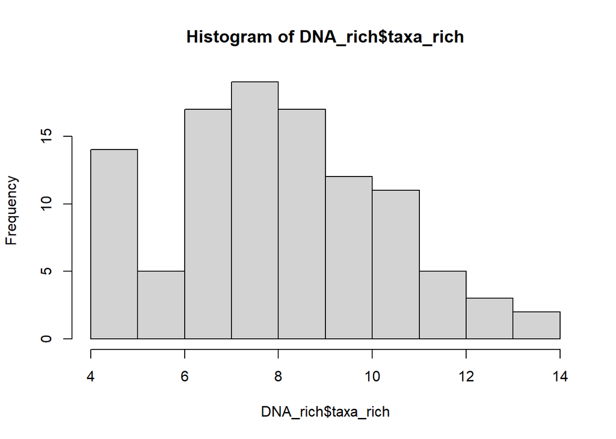

```r
hist(DNA_rich$taxa_rich)
```

distribution more or less normally distributed.

```r
DNA_rich_inter <- lsmeans(DNA_rich_lmer2, ~ treatment | timepoint )

DNA_rich_inter_dunn1 <- contrast(DNA_rich_inter, 'pairwise')
(DNA_rich_inter_dunn_sum1 <- summary(DNA_rich_inter_dunn1, infer = TRUE, adjust = 'mvt'))
```

```
## timepoint = April:
##  contrast            estimate     SE  df asymp.LCL asymp.UCL z.ratio p.value
##  forest - transplant  -0.0176 0.0804 Inf   -0.2060     0.171  -0.219  0.9739
##  forest - viti         0.1381 0.0837 Inf   -0.0579     0.334   1.651  0.2242
##  transplant - viti     0.1558 0.0834 Inf   -0.0396     0.351   1.868  0.1479
##
## timepoint = June:
##  contrast            estimate     SE  df asymp.LCL asymp.UCL z.ratio p.value
##  forest - transplant  -0.0176 0.0804 Inf   -0.2059     0.171  -0.219  0.9739
##  forest - viti         0.1381 0.0837 Inf   -0.0579     0.334   1.651  0.2242
##  transplant - viti     0.1558 0.0834 Inf   -0.0396     0.351   1.868  0.1479
##
## timepoint = August:
##  contrast            estimate     SE  df asymp.LCL asymp.UCL z.ratio p.value
##  forest - transplant  -0.0176 0.0804 Inf   -0.2060     0.171  -0.219  0.9739
##  forest - viti         0.1381 0.0837 Inf   -0.0580     0.334   1.651  0.2243
##  transplant - viti     0.1558 0.0834 Inf   -0.0397     0.351   1.868  0.1479
##
## timepoint = September:
##  contrast            estimate     SE  df asymp.LCL asymp.UCL z.ratio p.value
##  forest - transplant  -0.0176 0.0804 Inf   -0.2060     0.171  -0.219  0.9739
##  forest - viti         0.1381 0.0837 Inf   -0.0580     0.334   1.651  0.2242
##  transplant - viti     0.1558 0.0834 Inf   -0.0396     0.351   1.868  0.1479
##
## Results are given on the log (not the response) scale.
## Confidence level used: 0.95
## Conf-level adjustment: mvt method for 3 estimates
## P value adjustment: mvt method for 3 tests
```

within time points no significant difference. Only tendencies between transplant and cone of all four time points

since only time point was significant check differences between time points

```r
DNA_rich_inter2 <- lsmeans(DNA_rich_lmer2, ~ timepoint)

DNA_rich_inter_dunn2 <- contrast(DNA_rich_inter2, 'pairwise')
(DNA_rich_inter_dunn_sum2 <- summary(DNA_rich_inter_dunn2, infer = TRUE, adjust = 'mvt'))
```

```
##  contrast           estimate     SE  df asymp.LCL asymp.UCL z.ratio p.value
##  April - June        0.14232 0.0862 Inf   -0.0784     0.363   1.652  0.3465
##  April - August      0.32262 0.0889 Inf    0.0948     0.550   3.628  0.0015
##  April - September   0.31658 0.1070 Inf    0.0431     0.590   2.966  0.0158
##  June - August       0.18029 0.0932 Inf   -0.0585     0.419   1.934  0.2111
##  June - September    0.17425 0.1100 Inf   -0.1085     0.457   1.579  0.3877
##  August - September -0.00604 0.1130 Inf   -0.2943     0.282  -0.054  0.9999
##
## Results are averaged over the levels of: treatment
## Results are given on the log (not the response) scale.
## Confidence level used: 0.95
## Conf-level adjustment: mvt method for 6 estimates
## P value adjustment: mvt method for 6 tests
```

#### 3.2.7.1 create Figure S6 b

create plot of taxa richness of hyphymycetes identified via metabarcoding

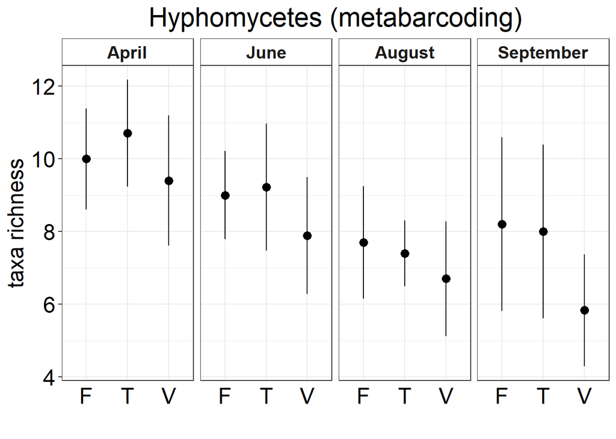

```r
tax_DNA_CI <- group.CI(taxa_rich ~ timepoint + treatment,
                   data = DNA_rich,
                   ci = 0.95)

# change order of factor
tax_DNA_CI$time.point <- factor(tax_DNA_CI$timepoint,
                             levels = c("April", "June", "August", "September"))

# rename transplant treatments in order to enable fit to the plot
tax_DNA_CI$treatment <- gsub("transplant", "T", tax_DNA_CI$treatment)
tax_DNA_CI$treatment <- gsub("forest", "F", tax_DNA_CI$treatment)
tax_DNA_CI$treatment <- gsub("viti", "V", tax_DNA_CI$treatment)


p1_tax_DNA <-  ggplot(tax_DNA_CI, aes(x = treatment, y = taxa_rich.mean)) +
  geom_pointrange(data = tax_DNA_CI, aes(y = taxa_rich.mean, ymin = taxa_rich.lower, ymax = taxa_rich.upper))+
  geom_point(data = tax_DNA_CI, mapping = aes(y = taxa_rich.mean), size = 3) +
  facet_wrap(~timepoint, nrow = 1) +
  ylab('taxa richness')+
  xlab("")+
  ggtitle("Hyphomycetes (metabarcoding)")+
  theme_bw()+
  theme(axis.text.x = element_text(size = 18, color="black"), axis.ticks.x = element_blank(),
         axis.text.y = element_text(colour="black", size = 18),
         legend.position="none", strip.text.x = element_text(face = "bold"),
         text = element_text(size=18), plot.title = element_text(hjust = 0.5),strip.background = element_rect(fill="white"))

p1_tax_DNA
```

save one figures with all richness plots

```r
fig_S6_richness <-ggarrange(p1_taxa, p1_tax_DNA, p1_ASV_hyph, p1_ASV, nrow = 2, ncol= 2, labels = c("(a)","(b)", "(c)", "(d)"))


svg(filename="Figure_S6_richness.svg", width=16.5, height=15, pointsize=11)
fig_S6_richness
dev.off()
```

```r
# p1_taxa # A
# p1_tax_DNA # B
# p1_ASV_hyph # C
# p1_ASV # D
```

### 3.2.8 IndVal

#### 3.2.8.1 species level via metabarcoding

identify indicator taxa for timepoints / treatments

for time point

```r
indval_DNA_tp = multipatt(DNA_taxa_hyph, DNA_expl$timepoint,
                   control = how(nperm=999))

summary(indval_DNA_tp, indvalcomp=TRUE)
```

```
##
##  Multilevel pattern analysis
##  ---------------------------
##
##  Association function: IndVal.g
##  Significance level (alpha): 0.05
##
##  Total number of species: 36
##  Selected number of species: 9
##  Number of species associated to 1 group: 2
##  Number of species associated to 2 groups: 5
##  Number of species associated to 3 groups: 2
##
##  List of species associated to each combination:
##
##  Group April  #sps.  1
##                              A      B  stat p.value
## Filosporella annelidica 0.9094 0.9333 0.921   0.001 ***
##
##  Group September  #sps.  1
##                                A      B  stat p.value
## Triscelophorus monosporus 0.9199 0.1765 0.403   0.023 *
##
##  Group April+June  #sps.  2
##                               A      B  stat p.value
## Lemonniera centrosphaera 0.8720 0.8793 0.876   0.001 ***
## Tetracladium sp.         0.9103 0.7414 0.822   0.001 ***
##
##  Group April+September  #sps.  2
##                                A      B  stat p.value
## Flagellospora fusarioides 0.8511 0.7021 0.773   0.002 **
## Mycoarthris corallina     0.9516 0.3830 0.604   0.002 **
##
##  Group August+September  #sps.  1
##                                A      B  stat p.value
## Campylospora chaetocladia 1.0000 0.2128 0.461   0.006 **
##
##  Group April+June+August  #sps.  1
##                        A      B  stat p.value
## Dimorphospora sp. 0.9940 0.7386 0.857   0.001 ***
##
##  Group June+August+September  #sps.  1
##                           A      B  stat p.value
## Tetrachaetum elegans 0.9637 0.7333 0.841   0.004 **
## ---
## Signif. codes:  0 '***' 0.001 '**' 0.01 '*' 0.05 '.' 0.1 ' ' 1
```

A = specificity or positive predictive value B = fidelity or sensitivity

for treatment

```r
indval_DNA_tr = multipatt(DNA_taxa_hyph, DNA_expl$treatment,
                   control = how(nperm=999))

summary(indval_DNA_tr, indvalcomp=TRUE)
```

```
##
##  Multilevel pattern analysis
##  ---------------------------
##
##  Association function: IndVal.g
##  Significance level (alpha): 0.05
##
##  Total number of species: 36
##  Selected number of species: 4
##  Number of species associated to 1 group: 1
##  Number of species associated to 2 groups: 3
##
##  List of species associated to each combination:
##
##  Group viti  #sps.  1
##                                A      B stat p.value
## Triscelophorus monosporus 0.9825 0.1714 0.41   0.003 **
##
##  Group forest+transplant  #sps.  3
##                              A      B  stat p.value
## Tricladium splendens    0.9469 0.9143 0.930   0.001 ***
## Dimorphospora sp.       0.8404 0.8000 0.820   0.001 ***
## Filosporella annelidica 0.9033 0.6857 0.787   0.008 **
## ---
## Signif. codes:  0 '***' 0.001 '**' 0.01 '*' 0.05 '.' 0.1 ' ' 1
```

for streams

```r
indval_DNA_s = multipatt(DNA_taxa_hyph, DNA_expl$Stream,
                   control = how(nperm=999))

summary(indval_DNA_s, indvalcomp=TRUE)
```

```
##
##  Multilevel pattern analysis
##  ---------------------------
##
##  Association function: IndVal.g
##  Significance level (alpha): 0.05
##
##  Total number of species: 36
##  Selected number of species: 12
##  Number of species associated to 1 group: 3
##  Number of species associated to 2 groups: 1
##  Number of species associated to 3 groups: 1
##  Number of species associated to 4 groups: 0
##  Number of species associated to 5 groups: 1
##  Number of species associated to 6 groups: 1
##  Number of species associated to 7 groups: 1
##  Number of species associated to 8 groups: 4
##  Number of species associated to 9 groups: 0
##
##  List of species associated to each combination:
##
##  Group Dierbach  #sps.  1
##                                    A      B  stat p.value
## Hymenoscyphus varicosporoides 0.9308 0.5556 0.719   0.001 ***
##
##  Group Kaiserbach  #sps.  1
##                           A      B  stat p.value
## Tricladium angulatum 1.0000 0.1818 0.426   0.028 *
##
##  Group Russbach  #sps.  1
##                        A      B  stat p.value
## Varicosporium sp. 0.7043 0.3333 0.485   0.014 *
##
##  Group Hainbach+Isenach  #sps.  1
##                             A      B  stat p.value
## Mycofalcella calcarata 0.8363 0.4286 0.599   0.001 ***
##
##  Group Kropsbach+Modenbach+Triefenbach  #sps.  1
##                                A      B stat p.value
## Campylospora chaetocladia 0.9705 0.2581  0.5   0.023 *
```

[output cut: 15 more lines]

```
## Lemonniera centrosphaera 0.9392 0.7738 0.853   0.043 *
##
##  Group Dierbach+Hainbach+Isenach+Klingbach+Kropsbach+Modenbach+Otterbach+Triefenbach  #sps.  1
##                           A      B stat p.value
## Tetrachaetum elegans 0.9683 0.7647 0.86   0.003 **
##
##  Group Dierbach+Kaiserbach+Klingbach+Kropsbach+Modenbach+Otterbach+Russbach+Triefenbach  #sps.  1
##                                A      B  stat p.value
## Flagellospora fusarioides 0.9731 0.6071 0.769    0.04 *
##
##  Group Hainbach+Kaiserbach+Klingbach+Kropsbach+Modenbach+Otterbach+Russbach+Triefenbach  #sps.  1
##                                A      B  stat p.value
## Tetracladium marchalianum 0.9813 0.9524 0.967   0.001 ***
## ---
## Signif. codes:  0 '***' 0.001 '**' 0.01 '*' 0.05 '.' 0.1 ' ' 1
```

#### 3.2.8.2 ASVs

identify indicator ASVs for timepoints / treatments

for time point

```r
indval_DNA_tp = multipatt(DNA_hyph, DNA_expl$timepoint,
                   control = how(nperm=999))

summary(indval_DNA_tp, indvalcomp=TRUE)
```

```
##
##  Multilevel pattern analysis
##  ---------------------------
##
##  Association function: IndVal.g
##  Significance level (alpha): 0.05
##
##  Total number of species: 171
##  Selected number of species: 21
##  Number of species associated to 1 group: 11
##  Number of species associated to 2 groups: 5
##  Number of species associated to 3 groups: 5
##
##  List of species associated to each combination:
##
##  Group April  #sps.  8
##             A      B  stat p.value
## ASV9   0.9158 0.8333 0.874   0.001 ***
## ASV14  0.8951 0.4667 0.646   0.001 ***
## ASV47  0.9350 0.4333 0.637   0.001 ***
## ASV79  0.7843 0.2667 0.457   0.018 *
## ASV142 0.8601 0.2333 0.448   0.034 *
## ASV279 1.0000 0.1667 0.408   0.007 **
## ASV324 1.0000 0.1667 0.408   0.013 *
## ASV44  1.0000 0.1333 0.365   0.024 *
##
##  Group September  #sps.  3
##             A      B  stat p.value
## ASV12  0.8129 0.7059 0.758   0.001 ***
## ASV16  0.7854 0.5882 0.680   0.001 ***
## ASV357 0.9199 0.1765 0.403   0.018 *
##
##  Group April+June  #sps.  2
##            A      B  stat p.value
## ASV50 0.8780 0.5000 0.663   0.006 **
## ASV17 0.9680 0.2759 0.517   0.014 *
##
##  Group April+September  #sps.  2
##             A      B  stat p.value
## ASV116 0.9584 0.2766 0.515   0.004 **
## ASV54  0.9480 0.2766 0.512   0.017 *
##
##  Group August+September  #sps.  1
##            A      B  stat p.value
## ASV38 1.0000 0.2128 0.461    0.01 **
##
##  Group April+June+August  #sps.  2
##            A      B  stat p.value
## ASV24 0.9905 0.6932 0.829   0.002 **
## ASV34 1.0000 0.4773 0.691   0.001 ***
##
##  Group April+June+September  #sps.  2
##            A      B  stat p.value
## ASV18 0.9228 0.5200 0.693   0.014 *
## ASV56 0.9397 0.4133 0.623   0.006 **
##
##  Group June+August+September  #sps.  1
##           A      B stat p.value
## ASV3 0.9620 0.7333 0.84   0.002 **
## ---
## Signif. codes:  0 '***' 0.001 '**' 0.01 '*' 0.05 '.' 0.1 ' ' 1
```

A = specificity or positive predictive value B = fidelity or sensitivity

for treatment

```r
indval_DNA_tr = multipatt(DNA_hyph, DNA_expl$treatment,
                   control = how(nperm=999))

summary(indval_DNA_tr, indvalcomp=TRUE)
```

```
##
##  Multilevel pattern analysis
##  ---------------------------
##
##  Association function: IndVal.g
##  Significance level (alpha): 0.05
##
##  Total number of species: 171
##  Selected number of species: 11
##  Number of species associated to 1 group: 6
##  Number of species associated to 2 groups: 5
##
##  List of species associated to each combination:
##
##  Group viti  #sps.  6
##             A      B  stat p.value
## ASV47  0.7827 0.4000 0.560   0.004 **
## ASV55  0.9144 0.2286 0.457   0.001 ***
## ASV142 0.8030 0.2571 0.454   0.005 **
## ASV357 0.9825 0.1714 0.410   0.007 **
## ASV268 1.0000 0.1429 0.378   0.005 **
## ASV279 1.0000 0.1429 0.378   0.011 *
##
##  Group forest+transplant  #sps.  4
##            A      B  stat p.value
## ASV7  0.9466 0.9143 0.930   0.001 ***
## ASV24 0.8907 0.7571 0.821   0.001 ***
## ASV9  0.9276 0.5857 0.737   0.006 **
## ASV69 1.0000 0.1571 0.396   0.038 *
##
##  Group transplant+viti  #sps.  1
##           A      B  stat p.value
## ASV5 0.8712 0.7857 0.827   0.001 ***
## ---
## Signif. codes:  0 '***' 0.001 '**' 0.01 '*' 0.05 '.' 0.1 ' ' 1
```

for streams

```r
indval_DNA_s = multipatt(DNA_hyph, DNA_expl$Stream,
                   control = how(nperm=999))

summary(indval_DNA_s, indvalcomp=TRUE)
```

```
##
##  Multilevel pattern analysis
##  ---------------------------
##
##  Association function: IndVal.g
##  Significance level (alpha): 0.05
##
##  Total number of species: 171
##  Selected number of species: 41
##  Number of species associated to 1 group: 14
##  Number of species associated to 2 groups: 8
##  Number of species associated to 3 groups: 6
##  Number of species associated to 4 groups: 3
##  Number of species associated to 5 groups: 3
##  Number of species associated to 6 groups: 4
##  Number of species associated to 7 groups: 1
##  Number of species associated to 8 groups: 2
##  Number of species associated to 9 groups: 0
##
##  List of species associated to each combination:
##
##  Group Dierbach  #sps.  2
##             A      B  stat p.value
## ASV153 0.9308 0.5556 0.719   0.001 ***
## ASV135 0.8779 0.2222 0.442   0.045 *
##
##  Group Hainbach  #sps.  2
##             A      B  stat p.value
## ASV129 1.0000 0.2222 0.471   0.029 *
## ASV264 1.0000 0.2222 0.471   0.025 *
##
##  Group Kaiserbach  #sps.  1
##            A      B  stat p.value
## ASV59 0.9225 0.7273 0.819   0.001 ***
##
##  Group Kropsbach  #sps.  7
##             A      B  stat p.value
## ASV246 0.8529 0.4286 0.605   0.001 ***
## ASV100 1.0000 0.2857 0.535   0.004 **
## ASV337 1.0000 0.2857 0.535   0.005 **
```

[output cut: 95 more lines]

```
## ASV4 0.9319 0.8167 0.872   0.001 ***
##
##  Group Dierbach+Kaiserbach+Klingbach+Kropsbach+Modenbach+Otterbach+Triefenbach  #sps.  1
##            A      B stat p.value
## ASV18 0.9444 0.5333 0.71   0.038 *
##
##  Group Dierbach+Hainbach+Isenach+Klingbach+Kropsbach+Modenbach+Otterbach+Triefenbach  #sps.  1
##           A      B  stat p.value
## ASV3 0.9653 0.7529 0.853   0.011 *
##
##  Group Dierbach+Hainbach+Isenach+Kropsbach+Modenbach+Otterbach+Russbach+Triefenbach  #sps.  1
##           A      B  stat p.value
## ASV9 0.9858 0.6220 0.783   0.002 **
## ---
## Signif. codes:  0 '***' 0.001 '**' 0.01 '*' 0.05 '.' 0.1 ' ' 1
```